# Разработка модели машинного обучения с целью расширения поголовья стада коров

# Описание проекта

Фермер, владелец молочного хозяйства, хочет купить бурёнок, чтобы расширить поголовье стада коров. Для этого он заключил выгодный контракт с ассоциацией пастбищ «Х». Условия позволяют фермеру очень тщательно отобрать коров. Он определяет качество молока по строгой методике, и при этом ему нужно выполнять свой план развития молочного хозяйства. Фермер хочет, чтобы каждая бурёнка давала не менее 6000 килограммов молока в год, а её надой был вкусным — строго по его критериям, ничуть не хуже. А продавцы и технологи так и норовят приукрасить своих коровок!

# Задача проекта

Разработать модель машинного обучения, которая будет управлять рисками и принимать объективное решение о покупке.

Необходимо создать две прогнозные модели для отбора бурёнок в поголовье:

- Первая будет прогнозировать возможный удой коровы.
- Вторая — рассчитывать вероятность получить вкусное молоко от коровы.

С помощью модели нужно отобрать коров по двум критериям:

- средний удой за год — не менее 6000 килограммов;
- молоко должно быть вкусным.

# Описание данных

**Файл `ferma_main.csv` содержит данные о стаде фермера на текущий момент.**

- `id` — уникальный идентификатор коровы.
- `Удой`, кг` — масса молока, которую корова даёт в год (в килограммах).
- `ЭКЕ` (Энергетическая кормовая единица)` — показатель питательности корма коровы.
- `Сырой протеин, г` — содержание сырого протеина в корме (в граммах).
- `СПО (Сахаро-протеиновое соотношение)` — отношение сахара к протеину в корме коровы.
- `Порода` — порода коровы.
- `Тип пастбища` — ландшафт лугов, на которых паслась корова.
- `порода папы_быка` — порода папы коровы.
- `Жирность,%` — содержание жиров в молоке (в процентах).
- `Белок,%` — содержание белков в молоке (в процентах).
- `Вкус молока` — оценка вкуса по личным критериям фермера, бинарный признак (вкусно, не вкусно).
- `Возраст` — возраст коровы, бинарный признак (менее_2_лет, более_2_лет).

Признаки в датасете `ferma_main.csv` можно разделить на группы.

- Характеристики коровы: `id`, `Порода`, `порода папы_быка`, `Возраст`.
- Характеристики корма: `ЭКЕ (Энергетическая кормовая единица)`, `Сырой протеин, г`, `СПО (Сахаро-протеиновое соотношение)`.
- Характеристика пастбища: `Тип пастбища`.
- Характеристики молока: `Удой, кг`, `Жирность,%`, `Белок,%`, `Вкус молока`.

Такое разделение поможет вам понять, как взаимосвязаны признаки в датасете.

**Файл `ferma_dad.csv` хранит имя папы каждой коровы в стаде фермера.**

- `id` — уникальный идентификатор коровы.
- `Имя Папы` — имя папы коровы.

**Файл `cow_buy_old.csv` — это данные о коровах «ЭкоФермы», которых фермер хочет изучить перед покупкой.**

- `Порода` — порода коровы.
- `Тип пастбища` — ландшафт лугов, на которых паслась корова.
- `порода папы_быка` — порода папы коровы.
- `Имя_папы` — имя папы коровы.
- `Текущая_жирность,%` — содержание жиров в молоке (в процентах).
- `Текущий_уровень_белок,%` — содержание белков в молоке (в процентах).
- `Возраст` — возраст коровы, бинарный признак (менее_2_лет, более_2_лет).

Данные в файлах `ferma_main.csv` и `cow_buy_old.csv` похожи, но у датасета `cow_buy_old.csv` несколько особенностей. Содержание белков и жиров в молоке указано на момент продажи — когда «ЭкоФерма» давала коровам свой корм. Параметры корма ЭКЕ (Энергетическая кормовая единица), Сырой протеин, г и СПО (Сахаро-протеиновое соотношение) отсутствуют. Технологи заказчика пересмотрели подход к кормлению: для новых коров планируется увеличить значения каждого из этих параметров на 5%. Кроме того, отсутствуют признаки Удой, кг и Вкус молока. Это целевые признаки, именно их предстоит предсказать!

# План работы

**Шаг 1. Загрузить и изучить данные**

1. Загрузить данные в датафреймы pandas.
- `/datasets/ferma_main.csv`
- `/datasets/ferma_dad.csv`
- `/datasets/cow_buy_old.csv`
1. Изучить данные. Определить, соответствуют ли они описанию задачи и стандартам оформления данных.

**Шаг 2. Предобработка данных**

Проверить данные на наличие пропусков и дубликатов. Посмотреть, корректны ли типы данных у каждого признака. При необходимости устранить все проблемы с данными.

**Шаг 3. Исследовательский анализ данных**

1. Провести статистический анализ всех признаков.
2. Построить графики для каждого признака (количественным и категориальным признакам подходят разные графики).
3. Сделать выводы о данных:
- заметили ли мы выбросы, необычное распределение количественных признаков или другие особенности;
- как мы планируем улучшить данные.

**Шаг 4. Корреляционный анализ признаков в датасете `ferma_main.csv`**

1. Изучить взаимосвязь между признаками: рассчитайте коэффициенты корреляции между всеми признаками.
2. Построить диаграммы рассеяния `scatterplot` для признака `Удой, кг` и всех количественных признаков с учётом значения категориальных признаков. Пример: диаграмма рассеяния для Удой, кг и Сырой протеин, г, цвет точек диаграммы отображает признак Порода. Учитывать, что виды связи в подгруппах могут различаться — например, для разных пород.
3. Сделать выводы о взаимосвязи признаков.
- Какой тип взаимосвязи между целевым и входными признаками?
- Есть ли нелинейные связи между целевым и входными признаками? Нужно ли вводить в модель дополнительные признаки, чтобы это учесть?
- Наблюдается ли мультиколлинеарность между входными признаками?

**Шаг 5. Задача регрессии** Предстоит обучить три модели простой линейной регрессии.

1. Подготовить данные датасета `ferma_main.csv` и обучить на них первую модель `LinearRegression`.
- Использовать в качестве целевого признак `Удой, кг`.
- Ототбрать признаки, которые подходят для модели линейной регрессии, аргументировать выбор. Опирайтесь не только на наличие или отсутствие линейной связи между признаками, но и на причинно-следственные связи между удоем коров и группами признаков из описания датасета.
- Разбить данные на тренировочную и тестовую выборки.
- Кодировать категориальные признаки с помощью `OneHotEncoder`.
- Масштабировать количественные признаки с помощью `StandardScaler`.
- Обучить модель линейной регрессии на подготовленных данных.
- Оценить качество модели на тестовой выборке: рассчитать R², проанализировать остатки с помощью графиков.
- Оформить выводы, указать:
  - значение R² модели;
  - какие выводы следуют из анализа остатков;
  - нужны ли дополнительные исследования.
1. Подготовить данные с учётом связи входных признаков с целевым и обучить на них вторую модель `LinearRegression`.
- Посмотреть на диаграммы рассеяния: на них можно увидеть, что некоторые входные признаки связаны с целевым нелинейно. Исключить нелинейность, чтобы эти признаки были информативны для линейной регрессии. Вот несколько способов, которыми это можно сделать:
  - Допустим, что `СПО` и `Удой` связаны нелинейно. На их диаграмме рассеяния наблюдения сгруппированы в два кластера, причём есть такое значение `СПО`, которое можно считать границей между кластерами. Чтобы устранить нелинейность, преобразуйте `СПО` в категориальный бинарный признак, использовав эту границу.
- Допустим, что `ЭКЕ` и `Удой` также связаны нелинейно. Нелинейность между ними можно исключить, если ввести новый признак `ЭКЕ в квадрате`.
- Повторите шаги из пункта 1 и создать вторую модель: подготовить данные, обучить модель, оценить её качество и написать выводы.
1. Добавить в данные новый признак и обучить на них третью модель `LinearRegression`.
- Добавить признак `Имя Папы` из файла `ferma_dad.csv`, соединив его с остальными данными `ferma_main.csv` по ключу.
- Устранить нелинейность между признаками.
- Повторить шаги из пункта 1 и создать третью модель: подготовить данные, обучить модель, оценить её качество и написать выводы.
1. Сравнить качество трёх моделей линейной регрессии, сопоставить их R² и остатки.
2. Оценить качество каждой модели по трём метрикам: MSE, MAE, RMSE. Использовать функции для расчёта метрик. Указать:
- лучшую модель;
- доверительный интервал прогноза лучшей модели.
1. С помощью лучшей модели спрогнозировать удой коров, которых фермер хочет купить. Данные о них находятся в датасете `cow_buy_old.csv`.
- Добавить недостающие признаки `ЭКЕ (Энергетическая кормовая единица)`, `Сырой протеин, г` и `СПО (Сахаро-протеиновое соотношение)`: взять из датасета `ferma_main.csv` средние значения каждого из признаков и увеличить их на 5%.
- Выполнить подготовку данных, аналогичную той, которую делали для тренировочной выборки.
- Получить прогноз удоя коров.

**Шаг 6. Задача классификации**

1. Подготовить данные датасета `ferma_main.csv` и обучите на них модель `LogisticRegression`.
- Использовать в качестве целевого признак `Вкус молока`.
- При необходимости преобразовать имеющиеся или добавить новые признаки.
- Разбить данные на тренировочную и тестовую выборки.
- Кодировать категориальные признаки с помощью `OneHotEncoder`.
- Масштабировать количественные признаки с помощью `StandardScaler`.
- Обучить модель логистической регрессии на подготовленных данных.
- Оценить качество модели на тестовой выборке: рассчитать метрики accuracy, recall, precision.
- Построить матрицу ошибок.
1. Проанализировать модель логистической регрессии.
- Объяснить, какая ошибка критичнее всего при покупке коров: первого или второго рода. Помните, что главное для заказчика — вкусное молоко. Сформулировать ответ с учётом метрик recall и precision, выбрать более важную из них.
- Свести критичную ошибку к нулю: для этого изменить порог принадлежности к классам. Ещё раз рассчитать значения метрик recall и precision.
- Оформить выводы: сказать, что нужно сделать дальше, исходя из анализа модели?
1. С помощью обученной модели спрогнозировать вкус молока коров, которых фермер хочет купить. Данные о них находятся в датасете `cow_buy_old.csv`.
- Выполнить подготовку данных, аналогичную той, которую делали для тренировочной выборки.
- Получите прогноз вкуса молока коров.

**Шаг 7. Сделайте итоговые выводы**

- Добавить прогнозы вкуса молока и удоя коров «ЭкоФермы» в датафрейм с коровами, покупку которых рассматривает фермер.
- Отобрать коров, для которых спрогнозирован удой более 6000 килограммов в год и вкусное молоко.
- Коротко описать результаты работы моделей для фермера.
  - Сколько коров он может купить из стада на продажу с минимальным риском для себя? Почему?
  - Какие ещё рекомендации можно ему дать?
- Сделать выводы о моделях линейной регрессии и логистической регрессии.
  - Какие способы улучшения качества регрессионной модели мы использовали в этой задаче?
  - Возможно ли ещё улучшить результаты регрессионной модели? Если можно, то как? Если нет, то почему
  - Какие метрики моделей классификации, в том числе логистической регрессии, важны при анализе рисков или экономических расчётов?

## Загрузка данных

На данном шаге нам необходимо загрузить необходимые библиотеки, загрузить и ознакомится с данными.

### Импортируем необходимые библиотеки

```python
import pandas as pd
import numpy as np
import seaborn as sns
import matplotlib.pyplot as plt
import scipy.stats as st

# импортируем класс LinearRegression, класс LogisticRegression и функцию для разделения данных
from sklearn.linear_model import LinearRegression
from sklearn.linear_model import LogisticRegression
from sklearn.model_selection import train_test_split

# импортируем функции для стандартизации, нормализации, кодирования
from sklearn.preprocessing import StandardScaler
from sklearn.preprocessing import MinMaxScaler
from sklearn.preprocessing import OneHotEncoder

# импортируем функции для R2 и MAE, MSE, RMSE
from sklearn.metrics import r2_score
from sklearn.metrics import mean_absolute_error
from sklearn.metrics import mean_squared_error

# импортируем функции для accuracy, precision, recall, confusion_matrix
from sklearn.metrics import accuracy_score
from sklearn.metrics import precision_score
from sklearn.metrics import recall_score
from sklearn.metrics import confusion_matrix
```

### Загрузим данные в датафреймы pandas.

```python
try:
    main = pd.read_csv('ferma_main.csv', sep = ';')
    dad = pd.read_csv('ferma_dad.csv',  sep = ';')
    cow_buy = pd.read_csv('cow_buy_old.csv', sep = ';')
except:
    main = pd.read_csv('https://code.s3.yandex.net/datasets/ferma_main.csv', sep = ';')
    dad = pd.read_csv('https://code.s3.yandex.net/datasets/ferma_dad.csv',  sep = ';')
    cow_buy = pd.read_csv('https://code.s3.yandex.net/datasets/cow_buy_old.csv',sep = ';')
```

### Изучим данные

```python
main.head(5)
```

|  | id | Удой, кг | ЭКЕ (Энергетическая кормовая единица) | Сырой протеин, г | СПО (Сахаро-протеиновое соотношение) | Порода | Тип пастбища | порода папы_быка | Жирность,% | Белок,% | Вкус молока | Возраст |
| --- | --- | --- | --- | --- | --- | --- | --- | --- | --- | --- | --- | --- |
| 0 | 1 | 5863 | 14,2 | 1743 | 0,89 | Вис Бик Айдиал | Равнинное | Айдиал | 3,58 | 3,076 | вкусно | более_2_лет |
| 1 | 2 | 5529 | 12,8 | 2138 | 0,89 | Вис Бик Айдиал | Равнинные | Соверин | 3,54 | 3,079 | вкусно | менее_2_лет |
| 2 | 3 | 5810 | 14 | 1854 | 0,885 | РефлешнСоверинг | Холмистое | Соверин | 3,59 | 3,074 | не вкусно | более_2_лет |
| 3 | 4 | 5895 | 12,4 | 2012 | 0,885 | РефлешнСоверинг | Холмистое | Айдиал | 3,4 | 3,075 | не вкусно | более_2_лет |
| 4 | 5 | 5302 | 12,8 | 1675 | 0,885 | Вис Бик Айдиал | Равнинные | Соверин | 3,73 | 3,073 | вкусно | менее_2_лет |

```python
main.info()
```

```
<class 'pandas.core.frame.DataFrame'>
RangeIndex: 634 entries, 0 to 633
Data columns (total 12 columns):
 #   Column                                 Non-Null Count  Dtype
---  ------                                 --------------  -----
 0   id                                     634 non-null    int64
 1   Удой, кг                               634 non-null    int64
 2   ЭКЕ (Энергетическая кормовая единица)  634 non-null    object
 3   Сырой протеин, г                       634 non-null    int64
 4   СПО (Сахаро-протеиновое соотношение)   634 non-null    object
 5   Порода                                 634 non-null    object
 6   Тип пастбища                           634 non-null    object
 7   порода папы_быка                       634 non-null    object
 8   Жирность,%                             634 non-null    object
 9   Белок,%                                634 non-null    object
 10  Вкус молока                            634 non-null    object
 11  Возраст                                634 non-null    object
dtypes: int64(3), object(9)
memory usage: 59.6+ KB
```

По первичной информации о датасете `main` можно сказать, что пропуски в данных отсутствуют, присутствуют неправильные типы данных, а также нестандартное оформление названия столбцов

```python
dad.head()
```

|  | id | Имя Папы |
| --- | --- | --- |
| 0 | 1 | Буйный |
| 1 | 2 | Соловчик |
| 2 | 3 | Барин |
| 3 | 4 | Буйный |
| 4 | 5 | Барин |

```python
dad.info()
```

```
<class 'pandas.core.frame.DataFrame'>
RangeIndex: 629 entries, 0 to 628
Data columns (total 2 columns):
 #   Column    Non-Null Count  Dtype
---  ------    --------------  -----
 0   id        629 non-null    int64
 1   Имя Папы  629 non-null    object
dtypes: int64(1), object(1)
memory usage: 10.0+ KB
```

По первичной информации о датасете `dad` можно сказать, что пропуски в данных отсутствуют, присутствует нестандартное оформление названия столбцов

```python
cow_buy.head()
```

|  | Порода | Тип пастбища | порода папы_быка | Имя_папы | Текущая_жирность,% | Текущий_уровень_белок,% |
| --- | --- | --- | --- | --- | --- | --- |
| 0 | Вис Бик Айдиал | холмистое | Айдиал | Геркулес | 3,58 | 3,076 |
| 1 | Вис Бик Айдиал | равнинное | Соверин | Буйный | 3,54 | 3,081 |
| 2 | РефлешнСоверинг | равнинное | Соверин | Барин | 3,59 | 3,074 |
| 3 | РефлешнСоверинг | холмистое | Айдиал | Буйный | 3,4 | 3,061 |
| 4 | РефлешнСоверинг | равнинное | Айдиал | Буйный | 3,64 | 3,074 |

```python
cow_buy.info()
```

```
<class 'pandas.core.frame.DataFrame'>
RangeIndex: 20 entries, 0 to 19
Data columns (total 6 columns):
 #   Column                   Non-Null Count  Dtype
---  ------                   --------------  -----
 0   Порода                   20 non-null     object
 1   Тип пастбища             20 non-null     object
 2   порода папы_быка         20 non-null     object
 3   Имя_папы                 20 non-null     object
 4   Текущая_жирность,%       20 non-null     object
 5   Текущий_уровень_белок,%  20 non-null     object
dtypes: object(6)
memory usage: 1.1+ KB
```

По первичной информации о датасете `cow_buy` можно сказать, что пропуски в данных отсутствуют, присутствуют неправильные типы данных, а также нестандартное оформление названия столбцов

### Приведем названия столбцов к стандартам оформления данных

```python
main = main.rename(columns={'Удой, кг':'yield_kg',
                            'ЭКЕ (Энергетическая кормовая единица)':'energy_feed_unit',
                            'Сырой протеин, г':'raw_protein_g',
                            'СПО (Сахаро-протеиновое соотношение)': 'sugar_protein_ratio',
                            'Порода':'breed', 'Тип пастбища':'type_pasture',
                            'порода папы_быка':'breed_daddy',
                            'Жирность,%':'fat_perc',
                            'Белок,%':'protein_perc',
                            'Вкус молока':'taste_milk',
                            'Возраст':'age'})
main.head(3)
```

|  | id | yield_kg | energy_feed_unit | raw_protein_g | sugar_protein_ratio | breed | type_pasture | breed_daddy | fat_perc | protein_perc | taste_milk | age |
| --- | --- | --- | --- | --- | --- | --- | --- | --- | --- | --- | --- | --- |
| 0 | 1 | 5863 | 14,2 | 1743 | 0,89 | Вис Бик Айдиал | Равнинное | Айдиал | 3,58 | 3,076 | вкусно | более_2_лет |
| 1 | 2 | 5529 | 12,8 | 2138 | 0,89 | Вис Бик Айдиал | Равнинные | Соверин | 3,54 | 3,079 | вкусно | менее_2_лет |
| 2 | 3 | 5810 | 14 | 1854 | 0,885 | РефлешнСоверинг | Холмистое | Соверин | 3,59 | 3,074 | не вкусно | более_2_лет |

```python
dad = dad.rename(columns={'Имя Папы':'name_daddy'})
dad.head(2)
```

|  | id | name_daddy |
| --- | --- | --- |
| 0 | 1 | Буйный |
| 1 | 2 | Соловчик |

```python
cow_buy = cow_buy.rename(columns={'Порода':'breed',
                                  'Тип пастбища':'type_pasture',
                                  'порода папы_быка':'breed_daddy',
                                  'Имя_папы':'name_daddy',
                                  'Текущая_жирность,%':'fat_perc',
                                  'Текущий_уровень_белок,%':'protein_perc',
                                  'Возраст':'age'})
cow_buy.head(3)
```

|  | breed | type_pasture | breed_daddy | name_daddy | fat_perc | protein_perc |
| --- | --- | --- | --- | --- | --- | --- |
| 0 | Вис Бик Айдиал | холмистое | Айдиал | Геркулес | 3,58 | 3,076 |
| 1 | Вис Бик Айдиал | равнинное | Соверин | Буйный | 3,54 | 3,081 |
| 2 | РефлешнСоверинг | равнинное | Соверин | Барин | 3,59 | 3,074 |

**Выводы по загрузке и изучению данных:**

- По первичной информации замечены неправильные типы данных, а также нестандартное оформление названия столбцов.
- Можно заметить, что пропусков в данных нет. Но также стоит учесть, что столбец `name_daddy` в датасете `dad` имеет 629 строк, а датасет `main` имеет 634 строк, то есть 5 строк из датасета `main`, при объединении с датасетом `dad`, будет иметь пять пропусков/дубликатов.

## Предобработка данных

На данном шаге проверим данные на наличие пропусков и дубликатов. Узнаем, корректны ли типы данных у каждого признака. При необходимости устраним все проблемы с данными.

### Проверим данные еще раз на наличие пропусков

Объединим датасеты `main` и `dad` по ключу `id`.

```python
main_dad = pd.merge(main, dad, how='left')
main_dad.head()
```

|  | id | yield_kg | energy_feed_unit | raw_protein_g | sugar_protein_ratio | breed | type_pasture | breed_daddy | fat_perc | protein_perc | taste_milk | age | name_daddy |
| --- | --- | --- | --- | --- | --- | --- | --- | --- | --- | --- | --- | --- | --- |
| 0 | 1 | 5863 | 14,2 | 1743 | 0,89 | Вис Бик Айдиал | Равнинное | Айдиал | 3,58 | 3,076 | вкусно | более_2_лет | Буйный |
| 1 | 2 | 5529 | 12,8 | 2138 | 0,89 | Вис Бик Айдиал | Равнинные | Соверин | 3,54 | 3,079 | вкусно | менее_2_лет | Соловчик |
| 2 | 3 | 5810 | 14 | 1854 | 0,885 | РефлешнСоверинг | Холмистое | Соверин | 3,59 | 3,074 | не вкусно | более_2_лет | Барин |
| 3 | 4 | 5895 | 12,4 | 2012 | 0,885 | РефлешнСоверинг | Холмистое | Айдиал | 3,4 | 3,075 | не вкусно | более_2_лет | Буйный |
| 4 | 5 | 5302 | 12,8 | 1675 | 0,885 | Вис Бик Айдиал | Равнинные | Соверин | 3,73 | 3,073 | вкусно | менее_2_лет | Барин |

Ниже проверим размерности датафреймов до объединения `main`, `dad` и после него `main_dad`.

```python
print('Размерность датафрейма main:', main.shape)
print('Размерность датафрейма dad:', dad.shape)
print('Размерность датафрейма main_dad:', main_dad.shape)
```

```
Размерность датафрейма main: (634, 12)
Размерность датафрейма dad: (629, 2)
Размерность датафрейма main_dad: (634, 13)
```

```python
main_dad.isna().sum()
```

```
id                     0
yield_kg               0
energy_feed_unit       0
raw_protein_g          0
sugar_protein_ratio    0
breed                  0
type_pasture           0
breed_daddy            0
fat_perc               0
protein_perc           0
taste_milk             0
age                    0
name_daddy             0
dtype: int64
```

```python
cow_buy.isna().sum()
```

```
breed           0
type_pasture    0
breed_daddy     0
name_daddy      0
fat_perc        0
protein_perc    0
dtype: int64
```

Пропуски не найдены. Проверим далее данные на дубликаты.

### Проверим данные на наличие неявных дубликатов и ошибок

Проверим данные датасета `main_dad` на наличие неявных дубликатов или ошибок в данных

```python
main_dad['breed'].unique()
```

```
array(['Вис Бик Айдиал', 'РефлешнСоверинг'], dtype=object)
```

```python
main_dad['type_pasture'].unique()
```

```
array(['Равнинное', 'Равнинные', 'Холмистое'], dtype=object)
```

```python
main_dad.loc[main_dad['type_pasture'] == 'Равнинное', 'type_pasture'] = 'равнинное'
main_dad.loc[main_dad['type_pasture'] == 'Равнинные', 'type_pasture'] = 'равнинное'
main_dad.loc[main_dad['type_pasture'] == 'Холмистое', 'type_pasture'] = 'холмистое'
main_dad['type_pasture'].unique()
```

```
array(['равнинное', 'холмистое'], dtype=object)
```

```python
main_dad['breed_daddy'].unique()
```

```
array(['Айдиал', 'Соверин', 'Айдиалл'], dtype=object)
```

```python
main_dad.loc[main_dad['breed_daddy'] == 'Айдиалл', 'breed_daddy'] = 'Айдиал'
main_dad['breed_daddy'].unique()
```

```
array(['Айдиал', 'Соверин'], dtype=object)
```

```python
main_dad['name_daddy'].unique()
```

```
array(['Буйный', 'Соловчик', 'Барин', 'Геркулес'], dtype=object)
```

```python
main_dad['taste_milk'].unique()
```

```
array(['вкусно', 'не вкусно'], dtype=object)
```

```python
main_dad['age'].unique()
```

```
array(['более_2_лет', 'менее_2_лет'], dtype=object)
```

Проверим данные датасета `cow_buy` на наличие неявных дубликатов или ошибок в данных

```python
cow_buy['breed'].unique()
```

```
array(['Вис Бик Айдиал', 'РефлешнСоверинг'], dtype=object)
```

```python
cow_buy['type_pasture'].unique()
```

```
array(['холмистое', 'равнинное'], dtype=object)
```

```python
cow_buy['breed_daddy'].unique()
```

```
array(['Айдиал', 'Соверин'], dtype=object)
```

```python
cow_buy['name_daddy'].unique()
```

```
array(['Геркулес', 'Буйный', 'Барин', 'Соловчик'], dtype=object)
```

Избавились от ошибок в данных. Далее проверим на наличие явных дубликатов.

Проверим на наличие неявных дубликатов в данных по набору столбцов

```python
main_dad[main_dad[
    ['yield_kg','breed','type_pasture', 'breed_daddy', 'age', 'fat_perc', 'protein_perc', 'name_daddy']
].duplicated(keep=False)]
```

|  | id | yield_kg | energy_feed_unit | raw_protein_g | sugar_protein_ratio | breed | type_pasture | breed_daddy | fat_perc | protein_perc | taste_milk | age | name_daddy |
| --- | --- | --- | --- | --- | --- | --- | --- | --- | --- | --- | --- | --- | --- |
| 626 | 627 | 5970 | 14,4 | 1837 | 0,88 | РефлешнСоверинг | холмистое | Соверин | 3,64 | 3,075 | не вкусно | более_2_лет | Барин |
| 629 | 627 | 5970 | 14,4 | 1837 | 0,88 | РефлешнСоверинг | холмистое | Соверин | 3,64 | 3,075 | не вкусно | более_2_лет | Барин |
| 630 | 627 | 5970 | 14,4 | 1837 | 0,88 | РефлешнСоверинг | холмистое | Соверин | 3,64 | 3,075 | не вкусно | более_2_лет | Барин |
| 631 | 627 | 5970 | 14,4 | 1837 | 0,88 | РефлешнСоверинг | холмистое | Соверин | 3,64 | 3,075 | не вкусно | более_2_лет | Барин |
| 632 | 627 | 5970 | 14,4 | 1837 | 0,88 | РефлешнСоверинг | холмистое | Соверин | 3,64 | 3,075 | не вкусно | более_2_лет | Барин |
| 633 | 627 | 5970 | 14,4 | 1837 | 0,88 | РефлешнСоверинг | холмистое | Соверин | 3,64 | 3,075 | не вкусно | более_2_лет | Барин |

```python
cow_buy[cow_buy[
    ['breed', 'type_pasture', 'breed_daddy', 'name_daddy', 'fat_perc', 'protein_perc']
].duplicated(keep=False)]
```

|  | breed | type_pasture | breed_daddy | name_daddy | fat_perc | protein_perc |
| --- | --- | --- | --- | --- | --- | --- |
| 0 | Вис Бик Айдиал | холмистое | Айдиал | Геркулес | 3,58 | 3,076 |
| 2 | РефлешнСоверинг | равнинное | Соверин | Барин | 3,59 | 3,074 |
| 4 | РефлешнСоверинг | равнинное | Айдиал | Буйный | 3,64 | 3,074 |
| 6 | Вис Бик Айдиал | холмистое | Айдиал | Геркулес | 3,58 | 3,076 |
| 8 | РефлешнСоверинг | равнинное | Соверин | Барин | 3,59 | 3,074 |
| 14 | РефлешнСоверинг | равнинное | Соверин | Барин | 3,59 | 3,074 |
| 19 | РефлешнСоверинг | равнинное | Айдиал | Буйный | 3,64 | 3,074 |

По датасету `cow_buy` выявлены неявные дубликаты по набору столбцов. Но мы не можем с полной уверенностью говорить, что это дубликаты, так как это больше похоже на нехватку дополнительной информации о коровах, так как информация, представленная в данном датасете представялет общую картину о коровах.

### Проверим данные на наличие явных дубликатов

```python
print('Количество явных дубликатов в датасете main_dad:', main_dad.duplicated().sum())
```

```
Количество явных дубликатов в датасете main_dad: 5
```

Избавимся от дубликтов в датасете `main_dad`

```python
main_dad = main_dad.drop_duplicates()
main_dad.duplicated().sum()
```

```
0
```

```python
print('Количество явных дубликатов в датасете cow_buy:', cow_buy.duplicated().sum())
```

```
Количество явных дубликатов в датасете cow_buy: 4
```

Избавимся от дубликтов в датасете `cow_buy`

```python
cow_buy = cow_buy.drop_duplicates()
#cow_buy.duplicated().sum()
```

Избавились от явных дубликатов. Далее преобразуем данные в нужные типы

### Преобразуем данные в нужные типы

```python
#main_dad.info()
#main_dad.head()
```

```python
main_dad['energy_feed_unit'] = main_dad['energy_feed_unit'].str.replace(',', '.').astype('float64')
main_dad['sugar_protein_ratio'] = main_dad['sugar_protein_ratio'].str.replace(',', '.').astype('float64')
main_dad['fat_perc'] = main_dad['fat_perc'].str.replace(',', '.').astype('float64')
main_dad['protein_perc'] = main_dad['protein_perc'].str.replace(',', '.').astype('float64')
```

```python
main_dad.info()
```

```
<class 'pandas.core.frame.DataFrame'>
Int64Index: 629 entries, 0 to 628
Data columns (total 13 columns):
 #   Column               Non-Null Count  Dtype
---  ------               --------------  -----
 0   id                   629 non-null    int64
 1   yield_kg             629 non-null    int64
 2   energy_feed_unit     629 non-null    float64
 3   raw_protein_g        629 non-null    int64
 4   sugar_protein_ratio  629 non-null    float64
 5   breed                629 non-null    object
 6   type_pasture         629 non-null    object
 7   breed_daddy          629 non-null    object
 8   fat_perc             629 non-null    float64
 9   protein_perc         629 non-null    float64
 10  taste_milk           629 non-null    object
 11  age                  629 non-null    object
 12  name_daddy           629 non-null    object
dtypes: float64(4), int64(3), object(6)
memory usage: 68.8+ KB
```

```python
#cow_buy.info()
#cow_buy.head()
```

```python
cow_buy['fat_perc'] = cow_buy['fat_perc'].str.replace(',', '.').astype('float64')
cow_buy['protein_perc'] = cow_buy['protein_perc'].str.replace(',', '.').astype('float64')
```

```python
cow_buy.info()
```

```
<class 'pandas.core.frame.DataFrame'>
Int64Index: 16 entries, 0 to 18
Data columns (total 6 columns):
 #   Column        Non-Null Count  Dtype
---  ------        --------------  -----
 0   breed         16 non-null     object
 1   type_pasture  16 non-null     object
 2   breed_daddy   16 non-null     object
 3   name_daddy    16 non-null     object
 4   fat_perc      16 non-null     float64
 5   protein_perc  16 non-null     float64
dtypes: float64(2), object(4)
memory usage: 896.0+ bytes
```

### Выводы по предобработке данных

По итогам предобработке данных:

- проверили пропуски в данных;
- проверили данные на явные и неявные пропуски и избавлись от них;
- преобразовали данные к правильному типу. Данные с плавающей запятой типа object были заменены на данные с плавающей точкой типа float64.

## Исследовательский анализ данных

На данном шаге необходимо провести статистический анализ данных,построить графики для каждого признака и сделать выводы по итогу анализа.

### Проведем статистический анализ всех признаков

```python
main_dad.describe()
```

|  | id | yield_kg | energy_feed_unit | raw_protein_g | sugar_protein_ratio | fat_perc | protein_perc |
| --- | --- | --- | --- | --- | --- | --- | --- |
| count | 629.00000 | 629.000000 | 629.000000 | 629.000000 | 629.000000 | 629.000000 | 629.000000 |
| mean | 315.00000 | 6188.750397 | 14.543879 | 1923.364070 | 0.913116 | 3.603657 | 3.075671 |
| std | 181.72094 | 1644.795489 | 1.306408 | 182.956251 | 0.032203 | 0.168656 | 0.002549 |
| min | 1.00000 | 5204.000000 | 10.900000 | 1660.000000 | 0.840000 | 2.990000 | 3.069000 |
| 25% | 158.00000 | 5751.000000 | 13.500000 | 1771.000000 | 0.890000 | 3.590000 | 3.074000 |
| 50% | 315.00000 | 6133.000000 | 14.700000 | 1888.000000 | 0.930000 | 3.650000 | 3.076000 |
| 75% | 472.00000 | 6501.000000 | 15.600000 | 2062.000000 | 0.940000 | 3.720000 | 3.077000 |
| max | 629.00000 | 45616.000000 | 16.800000 | 2349.000000 | 0.960000 | 3.750000 | 3.085000 |

По интернет-данным средний удой коровы в год составляет 5000-6000 кг. Высокомолочные породы имеют другие показатели. В среднем за год буренки дают от 9 000 до 14 000 кг.

Исходя из этого, в столбце `yield_kg` присутствуют выбросы. Необходимо от этих выбросов избавиться.

```python
main_dad = main_dad.query('yield_kg<=14000')
```

```python
main_dad.describe()
```

|  | id | yield_kg | energy_feed_unit | raw_protein_g | sugar_protein_ratio | fat_perc | protein_perc |
| --- | --- | --- | --- | --- | --- | --- | --- |
| count | 628.000000 | 628.000000 | 628.000000 | 628.000000 | 628.000000 | 628.000000 | 628.000000 |
| mean | 315.474522 | 6125.968153 | 14.548726 | 1923.759554 | 0.913089 | 3.604268 | 3.075670 |
| std | 181.475367 | 475.857053 | 1.301777 | 182.832816 | 0.032221 | 0.168093 | 0.002551 |
| min | 1.000000 | 5204.000000 | 10.900000 | 1660.000000 | 0.840000 | 2.990000 | 3.069000 |
| 25% | 158.750000 | 5749.750000 | 13.500000 | 1771.750000 | 0.890000 | 3.590000 | 3.074000 |
| 50% | 315.500000 | 6132.500000 | 14.700000 | 1888.000000 | 0.930000 | 3.650000 | 3.076000 |
| 75% | 472.250000 | 6501.000000 | 15.600000 | 2062.250000 | 0.940000 | 3.720000 | 3.077000 |
| max | 629.000000 | 7222.000000 | 16.800000 | 2349.000000 | 0.960000 | 3.750000 | 3.085000 |

```python
cow_buy.describe()
```

|  | fat_perc | protein_perc |
| --- | --- | --- |
| count | 16.000000 | 16.000000 |
| mean | 3.571875 | 3.068250 |
| std | 0.141620 | 0.011264 |
| min | 3.340000 | 3.046000 |
| 25% | 3.415000 | 3.059500 |
| 50% | 3.585000 | 3.073500 |
| 75% | 3.692500 | 3.076750 |
| max | 3.770000 | 3.081000 |

По статистическому анализу датасета `cow_buy`, не обнаружено выбросов

### Построим графики для каждого признака датасета `main_dad`

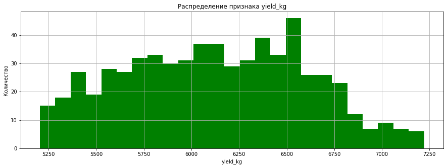

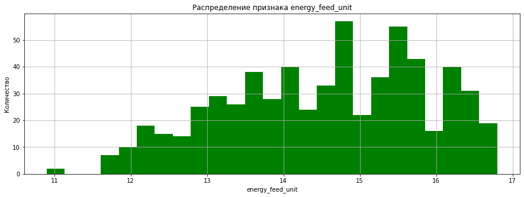

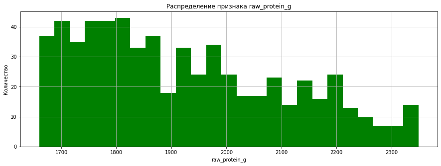

```python
for i in main_dad[['yield_kg', 'energy_feed_unit', 'raw_protein_g']]:
    main_dad[i].plot(kind='hist', grid=True, title= f'Распределение признака {i}', bins=25, color='green', figsize=(15,5));
    plt.xlabel(i)
    plt.ylabel('Количество')
    plt.show()
```

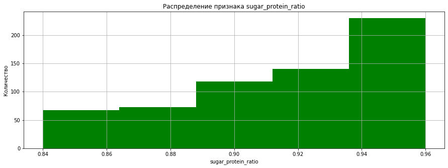

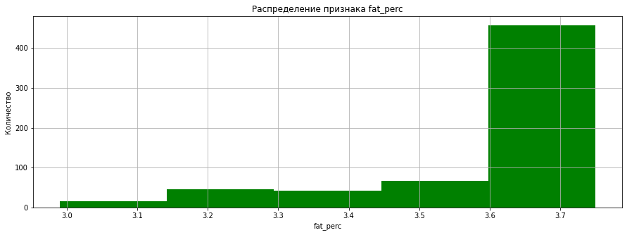

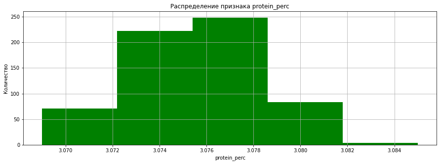

```python
for i in main_dad[['sugar_protein_ratio', 'fat_perc', 'protein_perc']]:
    main_dad[i].plot(kind='hist', grid=True, title= f'Распределение признака {i}', bins=5, color='green', figsize=(15,5));
    plt.xlabel(i)
    plt.ylabel('Количество')
    plt.show()
```

Также построим график "ящики с усами", который покажет выбросы и основные статистики данных (квартили)

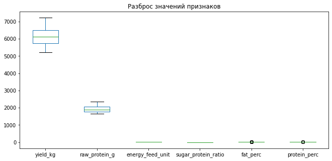

```python
main_dad[
    ['yield_kg', 'raw_protein_g', 'energy_feed_unit', 'sugar_protein_ratio', 'fat_perc', 'protein_perc']
].plot(kind='box', figsize=(11, 5))
plt.title('Разброс значений признаков')
plt.show();
```

Далее построим графики признаков в масштабированном формате, чтобы крупнее отразить боксплоты, вантили и медианы.

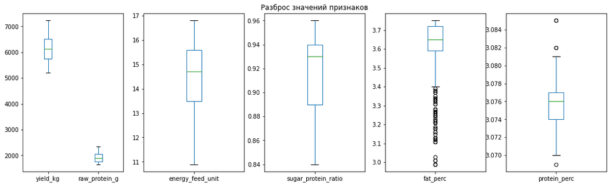

```python
fig, axes = plt.subplots(nrows=1, ncols=5, figsize=(18,5))
axes[2].set_title('Разброс значений признаков')
main_dad[['yield_kg', 'raw_protein_g']].plot(kind='box', ax=axes[0])
main_dad[['energy_feed_unit']].plot(kind='box', ax=axes[1])
main_dad['sugar_protein_ratio'].plot(kind='box', ax=axes[2])
main_dad['fat_perc'].plot(kind='box', ax=axes[3])
main_dad['protein_perc'].plot(kind='box', ax=axes[4])
plt.show();
```

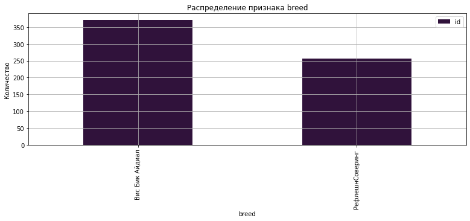

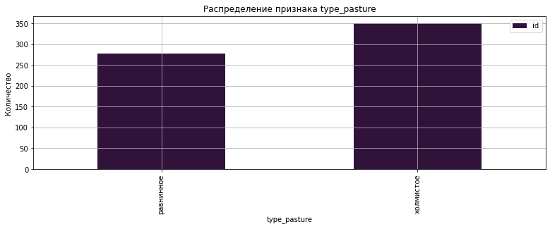

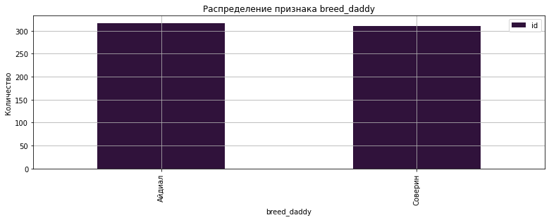

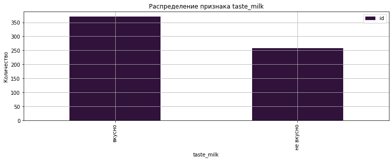

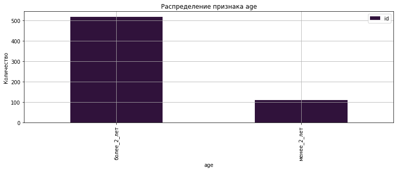

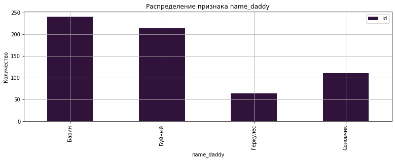

```python
for i in main_dad[['breed', 'type_pasture', 'breed_daddy', 'taste_milk', 'age', 'name_daddy']]:
    main_dad.pivot_table(index=i,
                         values='id',
                         aggfunc='count').plot(kind='bar',
                                               grid=True,
                                               title= f'Распределение признака {i}',
                                               colormap="turbo", figsize=(13,4));
    plt.xlabel(i)
    plt.ylabel('Количество')
    plt.show()
```

**Выводы по графикам качественных признаков:**

- По распределению признака породы коровы, можно сказать, что чаще встречаются коровы породы «Вис Бик Айдиал».
- По распределению признака типа пастбища, можно сказать, что чаще коровы пасутся на холмистых лугах.
- По распределению признака породы папы коровы, можно сказать, что примерно равномерно распределены по количеству коровы с породами папы коров.
- По распределению признака вкуса молока, можно сказать, что чаще молоко получается вкусным.
- По распределению признака возраста коровы, можно сказать, что наиболее чаще коровы имеют возраст более двух лет.
- По распределению имени папы коровы, можно сказать, что наиболее чаще встречаются коровы, имя папы которых является «Барин».

### Построим графики для каждого признака датасета `cow_buy`

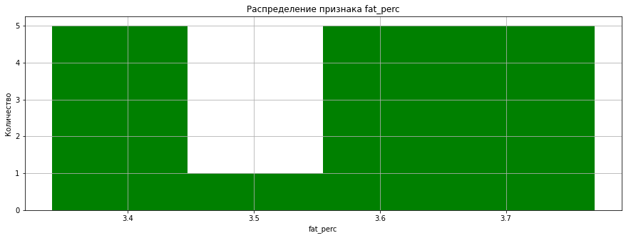

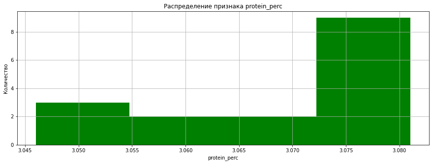

```python
for i in cow_buy[['fat_perc', 'protein_perc']]:
    cow_buy[i].plot(kind='hist', grid=True, title= f'Распределение признака {i}', bins=4, color='green', figsize=(15,5));
    plt.xlabel(i)
    plt.ylabel('Количество')
    plt.show()
```

**Выводы по графикам количественных признаков:**

- По распределению признака содержания жиров в молоке, можно сказать, что наиболее часто молоко коровы содержит 3.4% и 3.72% жиров.
- По распределению признака содержания протеина в молоке, можно сказать, что наиболее часто молоко коровы содержит 3.078% протеина.

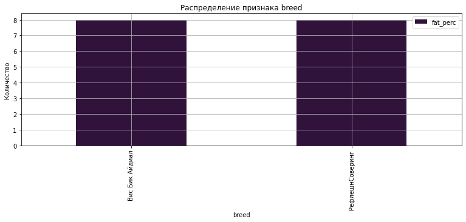

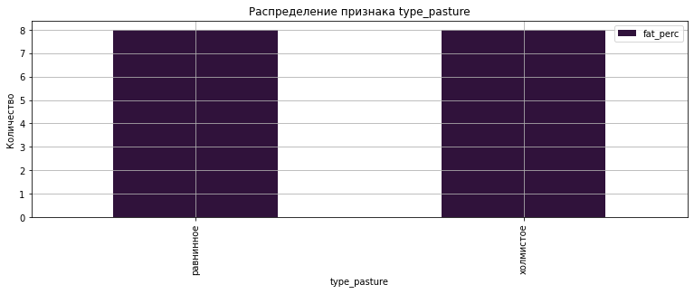

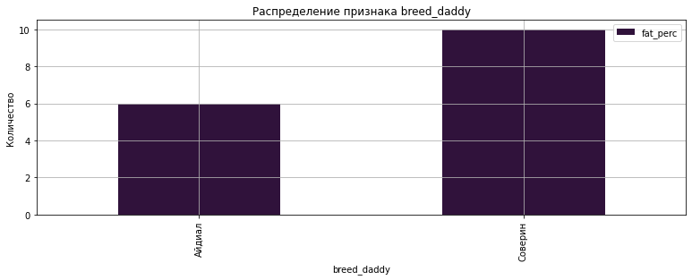

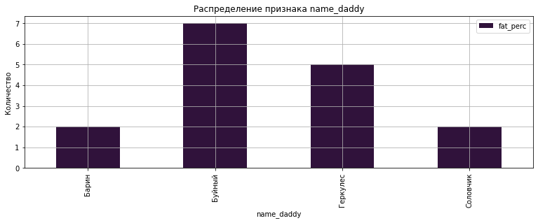

```python
for i in cow_buy[['breed', 'type_pasture', 'breed_daddy','name_daddy']]:
    cow_buy.pivot_table(index=i,
                        values='fat_perc',
                        aggfunc='count').plot(kind='bar',
                                              grid=True,
                                              title= f'Распределение признака {i}',
                                              colormap="turbo",
                                              figsize=(13,4));
    plt.xlabel(i)
    plt.ylabel('Количество')
    plt.show()
```

**Выводы по графикам качественных признаков:**

- По распределению признака породы коровы, можно сказать, что коровы примерно равномерно распределены по породам.
- По распределению признака типа пастбища, можно сказать, что коровы примерно равномерно распределены по местоположению пастбища.
- По распределению признака породы папы коровы, можно сказать, что наиболее чаще встречаются коровы, порода папы которых является «Соверин».
- По распределению имени папы коровы, можно сказать, что наиболее чаще встречаются коровы, имя папы которых является «Буйный».

### Вывод по исследовательскому анализу данных

- По интернет-данным средний удой коровы в год составляет 5000-6000 кг. Высокомолочные породы имеют другие показатели. В среднем за год буренки дают от 9 000 до 14 000 кг. Исходя из этого, по статистическому анализу датасета `main_dad`, в столбце `yield_kg` присутствовали выбросы, от которых мы избавились с помощью среза данных.
- По статистическому анализу датасета `cow_buy`, не обнаружено выбросов.

**По графикам, построенным по датасету `cow_buy`, можно сделать следующие выводы:**

- Наиболее часто молоко коровы содержит 3.4% и 3.72% жиров.
- Наиболее часто молоко коровы содержит 3.078% протеина.
- Коровы примерно равномерно распределены по породам.
- Коровы примерно равномерно распределены по местоположению пастбища.
- Чаще встречаются коровы, порода папы которых является «Соверин».
- Чаще встречаются коровы, имя папы которых является «Буйный».

## Корреляционный анализ

На данном этапе необходимо изучить взаимосвязь между признаками, определить тип взаимосвязи между целевым и входными признаками, определить есть ли нелинейные связи между целевым и входными признаками и наблюдается ли в данных мультиколлинеарность между входными признаками.

### Изучим взаимосвязь между признаками

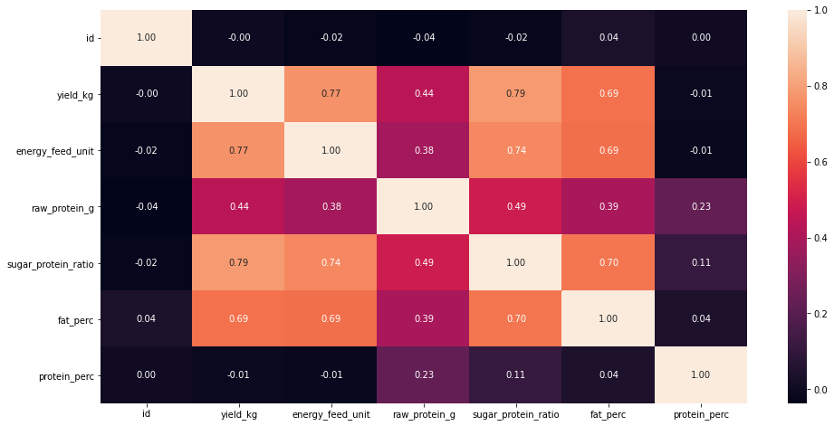

```python
fig, ax = plt.subplots(figsize=(16,8))
sns.heatmap(main_dad.corr(method='spearman'), annot=True, fmt='.2f', ax=ax);
```

По тепловой карте можно сделать следующие выводы о взаимосвязи между признаками:

- Высокая сила связи наблюдается между `energy_feed_unit` и `yield_kg`; `sugar_protein_ratio` и `yield_kg`; `sugar_protein_ratio` и `energy_feed_unit`; `fat_perc` и `sugar_protein_ratio`.
- Средняя сила связи наблюдается между `fat_perc` и `yield_kg`; `fat_perc` и `energy_feed_unit`;
- Слабая сила связи наблюдается между `raw_protein_g` и `yield_kg`; `raw_protein_g` и `energy_feed_unit`; `sugar_protein_ratio` и `raw_protein_g`; `fat_perc` и `raw_protein_g`.

Посмотрим на корреляцию признаков с учетом породы коров

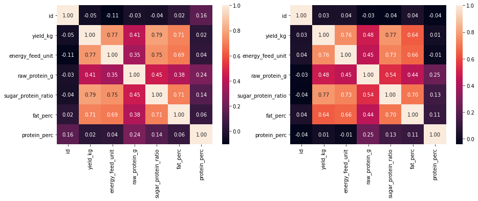

```python
fig, axes = plt.subplots(nrows=1, ncols=2, figsize=(15,5))
sns.heatmap(main_dad[main_dad['breed']=='Вис Бик Айдиал'].corr(method='spearman'), annot=True, fmt='.2f', ax=axes[0])
sns.heatmap(main_dad[main_dad['breed']=='РефлешнСоверинг'].corr(method='spearman'), annot=True, fmt='.2f', ax=axes[1]);
```

- Наибольшая взаимосвязь у коров породы "Вис Бик Айдиал" наблюдается между признаками: `yield_kg` и `sugar_protein_ratio` с процентом корреляции 0.79
- Наибольшая взаимосвязь у коров породы "РефлешнСоверинг" наблюдается между признаками: `yield_kg` и `sugar_protein_ratio` с процентом корреляции 0.77

Посмотрим на корреляцию признаков с учетом типов пастбищ

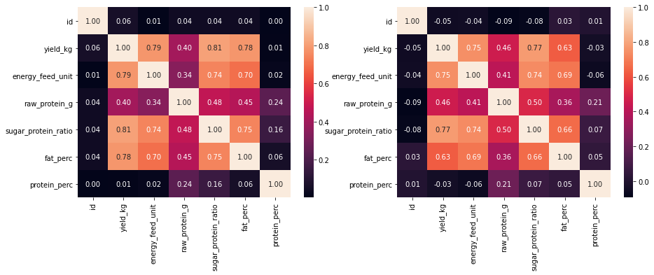

```python
fig, axes = plt.subplots(nrows=1, ncols=2, figsize=(15,5))
sns.heatmap(main_dad[main_dad['type_pasture']=='равнинное'].corr(method='spearman'), annot=True, fmt='.2f', ax=axes[0])
sns.heatmap(main_dad[main_dad['type_pasture']=='холмистое'].corr(method='spearman'), annot=True, fmt='.2f', ax=axes[1]);
```

- Наибольшая взаимосвязь у коров, которые паслись на равнинных холмах, наблюдается между признаками: `yield_kg` и `sugar_protein_ratio` с процентом корреляции 0.81
- Наибольшая взаимосвязь у коров, которые паслись на холмистых лугах, наблюдается между признаками: `yield_kg` и `sugar_protein_ratio` с процентом корреляции 0.77

Посмотрим на корреляцию признаков с учетом породы папы коровы

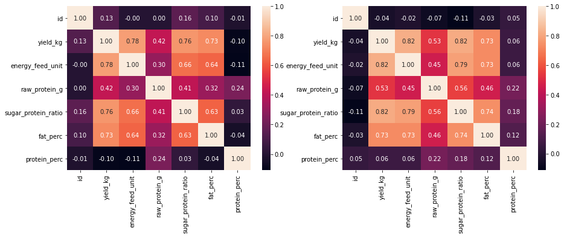

```python
fig, axes = plt.subplots(nrows=1, ncols=2, figsize=(15,5))
sns.heatmap(main_dad[main_dad['breed_daddy']=='Айдиал'].corr(method='spearman'), annot=True, fmt='.2f', ax=axes[0])
sns.heatmap(main_dad[main_dad['breed_daddy']=='Соверин'].corr(method='spearman'), annot=True, fmt='.2f', ax=axes[1]);
```

- Наибольшая взаимосвязь у коров, порода папы которых "Айдиал", наблюдается между признаками: `yield_kg` и `sugar_protein_ratio` с процентом корреляции 0.76 и `yield_kg` и `energy_feed_unit` с процентом корреляции 0.78
- Наибольшая взаимосвязь у коров, порода папы которых "Соверин", наблюдается между признаками: `yield_kg` и `sugar_protein_ratio` с процентом корреляции 0.82 и `yield_kg` и `energy_feed_unit` с процентом корреляции 0.82

Посмотрим на корреляцию признаков с учетом вкуса молока

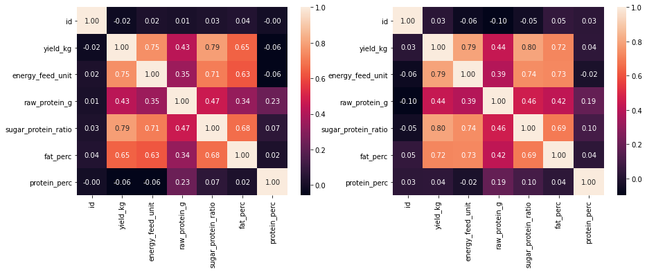

```python
fig, axes = plt.subplots(nrows=1, ncols=2, figsize=(15,5))
sns.heatmap(main_dad[main_dad['taste_milk']=='вкусно'].corr(method='spearman'), annot=True, fmt='.2f', ax=axes[0])
sns.heatmap(main_dad[main_dad['taste_milk']=='не вкусно'].corr(method='spearman'), annot=True, fmt='.2f', ax=axes[1]);
```

- Наибольшая взаимосвязь у коров, у которых получается вкусное молоко, наблюдается между признаками: `yield_kg` и `sugar_protein_ratio` с процентом корреляции 0.79
- Наибольшая взаимосвязь у коров, у которых получается невкусное молоко, наблюдается между признаками: `yield_kg` и `sugar_protein_ratio` с процентом корреляции 0.80

Посмотрим на корреляцию признаков с возраста коровы

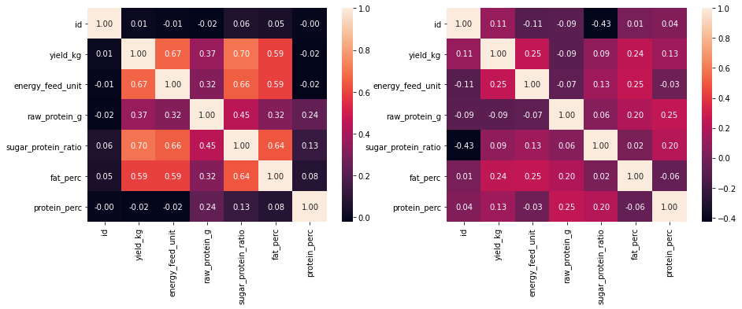

```python
fig, axes = plt.subplots(nrows=1, ncols=2, figsize=(15,5))
sns.heatmap(main_dad[main_dad['age']=='более_2_лет'].corr(method='spearman'), annot=True, fmt='.2f', ax=axes[0])
sns.heatmap(main_dad[main_dad['age']=='менее_2_лет'].corr(method='spearman'), annot=True, fmt='.2f', ax=axes[1]);
```

- Наибольшая взаимосвязь у коров в возрасте более 2х лет, наблюдается между признаками: `yield_kg` и `sugar_protein_ratio` с процентом корреляции 0.70
- У коров в возрасте менее двух лет, сильных взаимосвязей с признаками не наблюдается. Это говорит о том, что такие коровы, скорее всего, пока не дают молока, либо совсем немного, так как пик дачи молока обычно приходится на период от 3 до 7 лет.

### Посмотрим распредление удоя в зависимости от показателей

**Посмотрим распредление удоя в зависимости от показателя питательности корма коровы**

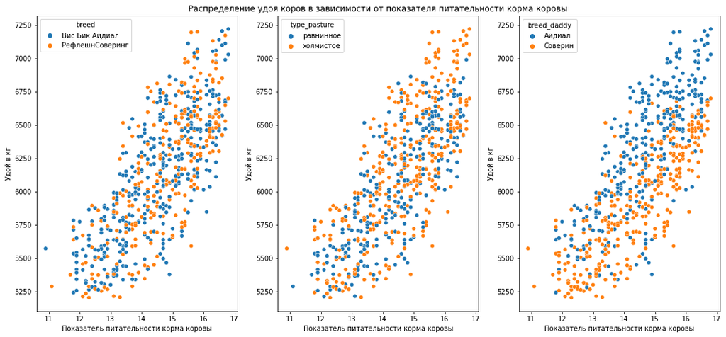

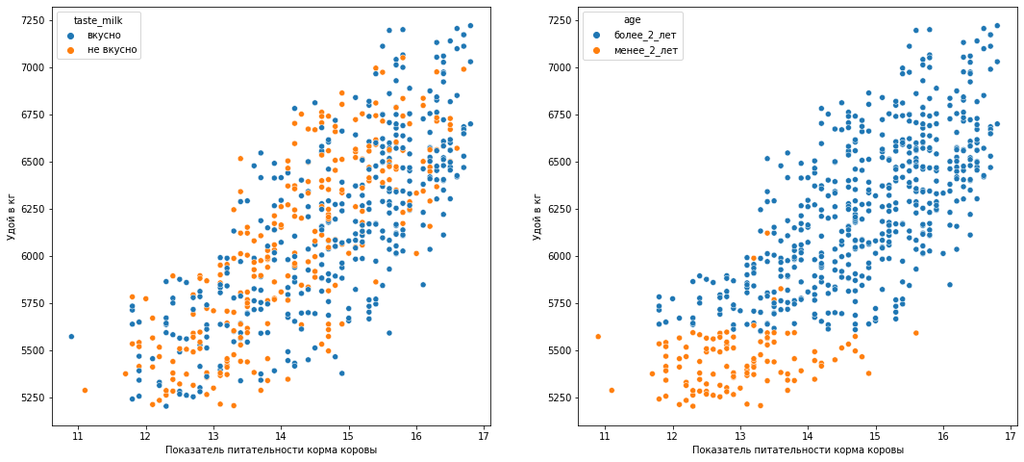

```python
fig, axes=plt.subplots(nrows=1,ncols=3, figsize=(18,8))
sns.scatterplot(x=main_dad['energy_feed_unit'], y=main_dad['yield_kg'], hue=main_dad['breed'], ax=axes[0])
axes[0].set_xlabel('Показатель питательности корма коровы')
axes[0].set_ylabel('Удой в кг')

sns.scatterplot(x=main_dad['energy_feed_unit'], y=main_dad['yield_kg'], hue=main_dad['type_pasture'], ax=axes[1])
axes[1].set_xlabel('Показатель питательности корма коровы')
axes[1].set_ylabel('Удой в кг')
axes[1].set_title('Распределение удоя коров в зависимости от показателя питательности корма коровы')

sns.scatterplot(x=main_dad['energy_feed_unit'], y=main_dad['yield_kg'], hue=main_dad['breed_daddy'], ax=axes[2])
axes[2].set_xlabel('Показатель питательности корма коровы')
axes[2].set_ylabel('Удой в кг')
plt.show()

fig, axes=plt.subplots(nrows=1,ncols=2, figsize=(18,8))
sns.scatterplot(x=main_dad['energy_feed_unit'], y=main_dad['yield_kg'], hue=main_dad['taste_milk'], ax=axes[0])
axes[0].set_xlabel('Показатель питательности корма коровы')
axes[0].set_ylabel('Удой в кг')

sns.scatterplot(x=main_dad['energy_feed_unit'], y=main_dad['yield_kg'], hue=main_dad['age'], ax=axes[1])
axes[1].set_xlabel('Показатель питательности корма коровы')
axes[1].set_ylabel('Удой в кг')
plt.show()
```

По данным графикам можно судить о положительной линейной зависимости. Причем, показатель питательности корма влияет больше на удой коров в возрасте более 2-х лет и у которых папа имеет породу "Айдиал".

**Посмотрим распредление удоя в зависимости от содержание сырого протеина в корме (в граммах)**

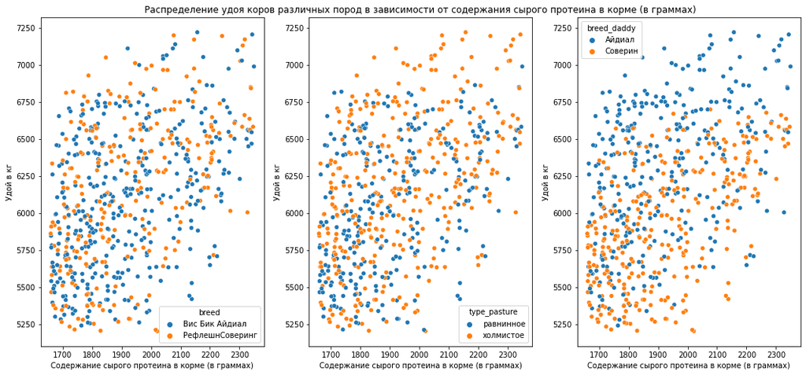

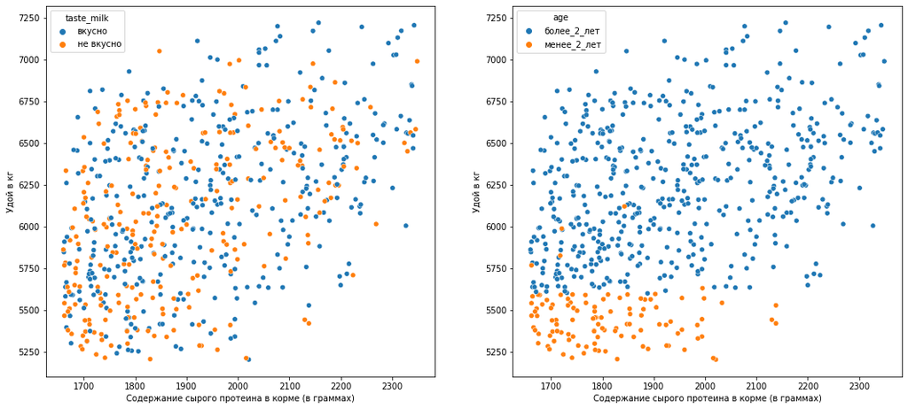

```python
fig, axes=plt.subplots(nrows=1,ncols=3, figsize=(18,8))
sns.scatterplot(x=main_dad['raw_protein_g'], y=main_dad['yield_kg'], hue=main_dad['breed'], ax=axes[0])
axes[0].set_xlabel('Cодержание сырого протеина в корме (в граммах)')
axes[0].set_ylabel('Удой в кг')

sns.scatterplot(x=main_dad['raw_protein_g'], y=main_dad['yield_kg'], hue=main_dad['type_pasture'], ax=axes[1])
axes[1].set_xlabel('Cодержание сырого протеина в корме (в граммах)')
axes[1].set_ylabel('Удой в кг')
axes[1].set_title('Распределение удоя коров различных пород в зависимости от содержания сырого протеина в корме (в граммах)')

sns.scatterplot(x=main_dad['raw_protein_g'], y=main_dad['yield_kg'], hue=main_dad['breed_daddy'], ax=axes[2])
axes[2].set_xlabel('Cодержание сырого протеина в корме (в граммах)')
axes[2].set_ylabel('Удой в кг')
plt.show()

fig, axes=plt.subplots(nrows=1,ncols=2, figsize=(18,8))
sns.scatterplot(x=main_dad['raw_protein_g'], y=main_dad['yield_kg'], hue=main_dad['taste_milk'], ax=axes[0])
axes[0].set_xlabel('Cодержание сырого протеина в корме (в граммах)')
axes[0].set_ylabel('Удой в кг')

sns.scatterplot(x=main_dad['raw_protein_g'], y=main_dad['yield_kg'], hue=main_dad['age'], ax=axes[1])
axes[1].set_xlabel('Cодержание сырого протеина в корме (в граммах)')
axes[1].set_ylabel('Удой в кг')
plt.show()
```